[figure not shown]

# MA660E, Lab Report

### Part One: Basic Charts and Summaries

#### Tasks:

- Create a **bar chart** for gender and a **pie chart** for ethnic group.
- Summarize the age data with a **five-number summary** (min, max, median, 1st quartile, 3rd quartile) and a **box plot**.
- Calculate the **mean** and **standard deviation** of income and create a **histogram**.

#### Solution:

#### **Bar Chart for Gender Distribution:**

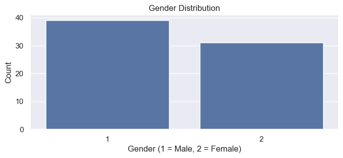

*Caption: A bar chart visualizing the gender distribution, with more male participants than female.*

#### **Pie Chart for Ethnic Groups:**

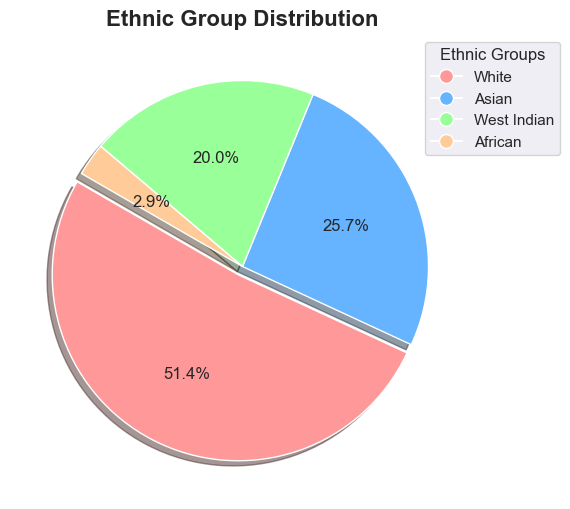

*Caption: A pie chart showing the distribution of ethnic groups, highlighting diversity in the dataset.*

#### **Table: Five-Number Summary for Age**

| Statistic | Value |
| --- | --- |
| Minimum | 18.0 |
| Q1 (25%) | 29.0 |
| Median | 39.0 |
| Q3 (75%) | 50.0 |
| Maximum | 63.0 |

*Caption: The five-number summary shows that the ages in the dataset range from 18 to 63, with a median of 39 years.*

#### **Box Plot for Age Distribution:**

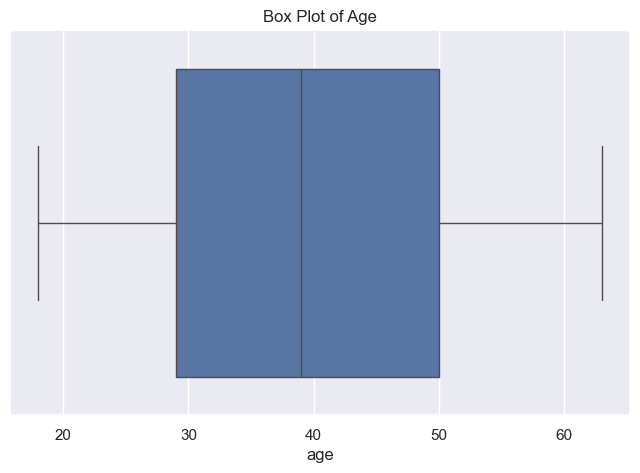

*Caption: A box plot representing the age distribution, showing that the majority of individuals are aged between 29 and 50.*

#### **Histogram of Income:**

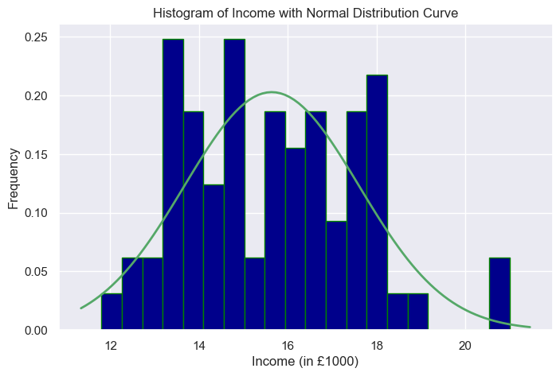

*Caption: The income histogram demonstrates that the majority of individuals have an income concentrated around the mean of 15.64.*

### Part one: 2. Scatter Plot and Regression

#### Tasks:

- Create a **scatter plot** to visualize the relationship between **income** and **absence**.
- Build a **simple linear regression model** with income as the dependent variable and absence as the independent variable.
- Report the determination coefficient (**R²**).

#### Solution:

#### **Scatter Plot: Relationship Between Income and Absence**

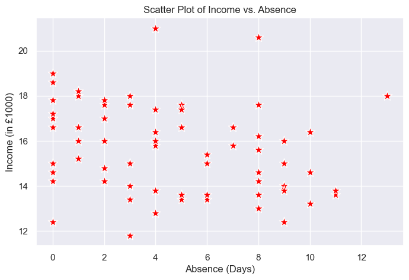

#### **Regression Model (Dropping Missing Values)**

- **R-squared (R²):** 0.0543

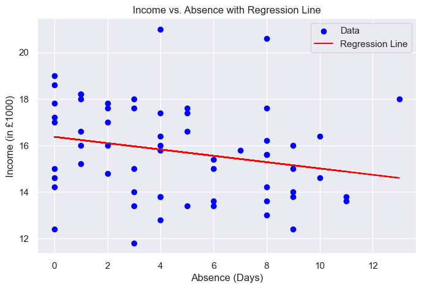

*Caption: Linear regression model after dropping rows with missing values. The R² value indicates a weak explanatory power of absence on income.*

#### **Regression Model (Filling Missing Values with Mean)**

- **R-squared (R²):** 0.0619

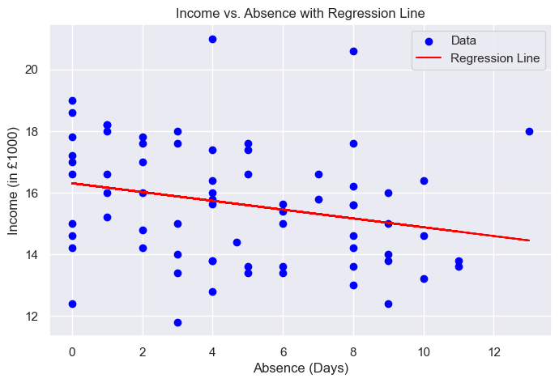

*Caption: Linear regression model with missing values filled by the mean. The slightly higher R² still suggests a weak relationship between absence and income.*

### Part One: 3. Multiple Regression Analysis

#### Tasks:

- Build a **multiple regression model** with **job satisfaction (satis)** as the dependent variable and the following as independent variables: **commitment (commit)**, **autonomy (autonom)**, **income**, **skill**, **qualification (qual)**, **age**, and **years** of experience.
- Identify **non-significant variables** and simplify the model by removing them.

#### Solution:

#### **Initial Multiple Regression Model**

The model explains 80.5% of the variance in job satisfaction. Significant predictors include commitment, autonomy, income, and skill, all positively affecting satisfaction. However, quality, age, and years of experience have little impact and can be excluded from the model.

[figure not shown]

#### **Refined Multiple Regression Model**

The refined model explains 80.5% of the variation in job satisfaction. It shows that commitment, autonomy, income, and skill all significantly contribute to higher job satisfaction. Quality is somewhat important but less impactful. Overall, the model suggests that focusing on commitment, autonomy, income, and skill is key to understanding job satisfaction.

[figure not shown]

### Part One: 4. Confidence Intervals

#### Task

In this section, we will calculate the confidence intervals for job satisfaction as well as the confidence interval for the difference between men and women.

#### Solution

- **Confidence Interval for Job Satisfaction (Satis):** (10.06, 11.61)
- **Confidence Interval for the Difference in Job Satisfaction between Men and Women:** (-1.38, 1.85)

## Part One: 5. Mann-Whitney and Kruskal-Wallis Tests

### Tasks:

- **Mann-Whitney-Wilcoxon Test:** Assess whether there is a significant difference in skill levels between men and women, and compare the results with the previously calculated confidence interval for job satisfaction.
- **Kruskal-Wallis Test:** Investigate if there is a significant difference in absence rates among different ethnic groups and compare the findings with those from the One-Way ANOVA test.

### Solution:

- **Mann-Whitney U Test:**
  - **Test Statistic:** 520.5
  - **p-value:** 0.4033
  - **Conclusion:** Fail to reject the null hypothesis; there is no significant difference in skill levels between men and women.
- **Kruskal-Wallis Test:**
  - **Test Statistic:** 2.4085
  - **p-value:** 0.4921
  - **Conclusion:** Fail to reject the null hypothesis; there is no significant difference in absence rates among ethnic groups.
- **One-Way ANOVA:**
  - **Test Statistic:** 0.8043
  - **p-value:** 0.4966
  - **Conclusion:** Fail to reject the null hypothesis; there is no significant difference in absence rates among ethnic groups.

### Summary:

The results from both the Mann-Whitney and Kruskal-Wallis tests indicate no significant differences in skill levels between genders or absence rates among ethnic groups. These findings are consistent with the conclusions drawn from the One-Way ANOVA.

## Part One: 6. Income Class Recode

### Tasks:

- **Recode Income:** Classify income into distinct categories based on the following ranges:
  - **Low Income Class:** [Min, Q1]
  - **Middle Income Class:** (Q1, Q3]
  - **High Income Class:** (Q3, Max]
- **Analysis:** Investigate if there is a significant relationship between income class and skill levels.

### Solution:

| No. | Income | Income Class |
| --- | --- | --- |
| 1 | 16.6 | Middle Income |
| 2 | 14.6 | Middle Income |
| 3 | 17.8 | High Income |
| 4 | 16.4 | Middle Income |
| 5 | 18.6 | High Income |

### Statistical Analysis:

- **Kruskal-Wallis Test:**
  - **Test Statistic:** 8.1833
  - **p-value:** 0.0167
  - **Conclusion:** Reject the null hypothesis; there is a significant relationship between income class and skill levels.

### Summary:

The results indicate a statistically significant relationship between the categorized income classes and skill, suggesting that income level may influence skill levels among individuals.

```python
import pandas as pd
import matplotlib.pyplot as plt
import seaborn as sns
import numpy as np
import sklearn
from sklearn.linear_model import LinearRegression
from sklearn.metrics import r2_score
import statsmodels.api as sm
from scipy.stats import mannwhitneyu
from scipy.stats import kruskal
from scipy.stats import f_oneway
from scipy import stats
from scipy.stats import norm
sns.set()
```

#### Cleaning and Preprocessing

- Converted 'income' from string format with commas to float.
- Replaced empty strings with NaN for handling missing values.
- Created two datasets: one with missing values replaced by the mean, and another with rows containing missing values removed.

```python
data_set = pd.read_csv('Data_source.csv', delimiter=';')
#data_set = pd.read_csv("Data_source.csv", sep=";" , decimal=',', na_values='')
data_set.columns = ['Id','ethnicgp', 'gender', 'age', 'years', 'commit',
'satis', 'autonom', 'routine', 'attend', 'skill', 'prody', 'qual', 'absence', 'income']



#clean dataset
null_values = data_set.isnull().sum()

# Filter and display only the columns with at least one null value
columns_with_null = null_values[null_values > 0]

for column, null_count in columns_with_null.items():
    print(f"{column}: {null_count} null values")

# Convert 'income' from string with commas to float
data_set['income'] = data_set['income'].str.replace(',', '.').astype(float)

# Replace empty strings with NaN for proper handling of missing values
data_set.replace('', pd.NA, inplace=True)

# Create dataset with missing values replaced by the mean
data_set_with_mean = data_set.copy()
for column in data_set_with_mean.columns:
    if data_set_with_mean[column].isnull().sum() > 0:  # Only fill columns with null values
        data_set_with_mean[column] = data_set_with_mean[column].fillna(data_set_with_mean[column].mean())


# Save the datasets
data_set_with_mean.to_csv('data_set_with_mean.csv', index=False)

# Display the shape of the new datasets
print(f"Dataset with mean imputation: {data_set_with_mean.shape}")

data_cleaned = data_set.dropna()
print(f"Dataset with rows removed: {data_cleaned.shape}")


data_set_with_mean.head()
```

```
age: 1 null values
years: 1 null values
commit: 2 null values
satis: 2 null values
prody: 1 null values
absence: 1 null values
income: 2 null values
Dataset with mean imputation: (70, 15)
Dataset with rows removed: (61, 15)
```

|  | Id | ethnicgp | gender | age | years | commit | satis | autonom | routine | attend | skill | prody | qual | absence | income |
| --- | --- | --- | --- | --- | --- | --- | --- | --- | --- | --- | --- | --- | --- | --- | --- |
| 0 | 1 | 1 | 1 | 29.0 | 1.0 | 4.0 | 10.838235 | 10 | 9 | 2 | 3 | 3.246377 | 1 | 7.0 | 16.6 |
| 1 | 2 | 2 | 1 | 26.0 | 5.0 | 2.0 | 10.838235 | 7 | 15 | 1 | 3 | 4.000000 | 4 | 8.0 | 14.6 |
| 2 | 3 | 3 | 1 | 40.0 | 5.0 | 4.0 | 15.000000 | 7 | 8 | 1 | 4 | 3.000000 | 4 | 0.0 | 17.8 |
| 3 | 4 | 3 | 1 | 46.0 | 15.0 | 2.0 | 7.000000 | 7 | 10 | 2 | 3 | 3.000000 | 4 | 4.0 | 16.4 |
| 4 | 5 | 2 | 2 | 63.0 | 36.0 | 4.0 | 14.000000 | 11 | 18 | 1 | 3 | 5.000000 | 3 | 0.0 | 18.6 |

### Part One: 1. Basic Charts and Summaries

- Create a bar chart for gender and a pie chart for ethnic group.
- Summarize the age data with a five-number summary (min, max, median, 1st quartile, 3rd quartile) and a box plot.
- Calculate the mean and standard deviation of income and create a histogram.

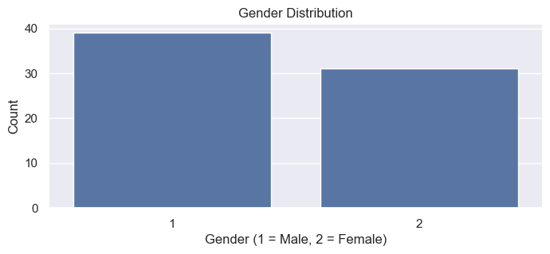

```python
plt.figure(figsize=(8,3))
sns.countplot(x='gender', data= data_set)
plt.title('Gender Distribution')
plt.xlabel('Gender (1 = Male, 2 = Female)')
plt.ylabel('Count')
plt.show()
```

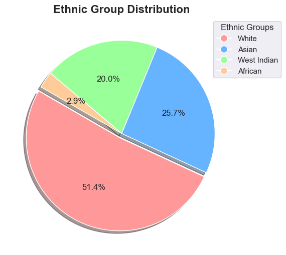

```python
ethnic_counts = data_set['ethnicgp'].value_counts()
ethnic_labels = ['White', 'Asian', 'West Indian', 'African']
colors = ['#ff9999', '#66b3ff', '#99ff99', '#ffcc99']
explode = (0.05, 0, 0, 0)
plt.figure(figsize = (6,7))

wedges, texts, autotexts = plt.pie(
    ethnic_counts,
    labels=None,
    autopct='%1.1f%%',
    startangle=150,
    colors=colors,
    explode=explode,
    shadow=True
)

# Step 4: Create a custom legend with stacked labels
# Create a list of handle objects for the legend
handles = []
for i, label in enumerate(ethnic_labels):
    handles.append(plt.Line2D([0], [0], marker='o', color='w', label=label,
                                markerfacecolor=colors[i], markersize=10))

# Add the legend to the plot
plt.legend(handles=handles, title='Ethnic Groups', loc='upper right', bbox_to_anchor=(1.2, 1))



plt.title('Ethnic Group Distribution', fontsize=16, fontweight='bold')
plt.show()
```

```
Five-Number Summary for Age:
min    18.0
25%    29.0
50%    39.0
75%    50.0
max    63.0
Name: age, dtype: float64
```

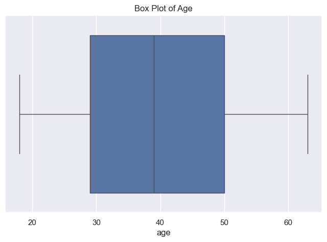

```python
age_summary = data_set['age'].describe()[['min', '25%', '50%', '75%', 'max']]
print("Five-Number Summary for Age:")
print(age_summary)

plt.figure(figsize=(8, 5))
sns.boxplot(x='age', data=data_set)
plt.title('Box Plot of Age')
plt.show()
```

```
Mean of Income: 15.638235294117644
Standard Deviation of Income: 1.9667548060645936
```

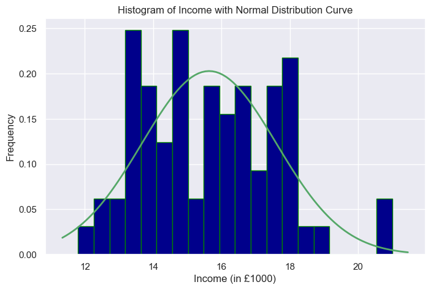

```python
income_mean = data_set['income'].mean()
income_std = data_set['income'].std()

print(f"Mean of Income: {income_mean}")
print(f"Standard Deviation of Income: {income_std}")

# Histogram of income
plt.figure(figsize=(8, 5))
plt.hist(data_set['income'], bins=20, color='darkblue', edgecolor='green', density=True)

xmin, xmax = plt.xlim()
x = np.linspace(xmin, xmax, 100)
p = norm.pdf(x, income_mean, income_std)

plt.plot(x, p, 'g', linewidth=2)

plt.title('Histogram of Income with Normal Distribution Curve')
plt.xlabel('Income (in £1000)')
plt.ylabel('Frequency')
plt.show()
```

#### Part One: 2. Scatter Plot and Regression

- Create a scatter plot to visualize the relationship between income and absence.
- Build a simple regression model with income as the dependent variable and absence as the independent variable. Report the determination coefficient (R²).

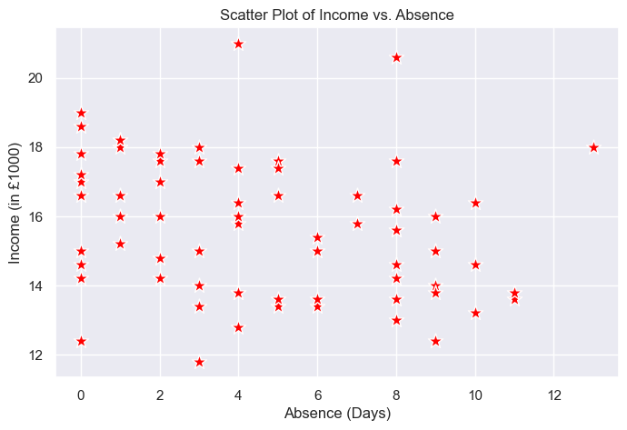

```python
plt.figure(figsize=(8, 5))
sns.scatterplot(x='absence', y='income', marker='*', c='red',s=150, data=data_set)
plt.title('Scatter Plot of Income vs. Absence')
plt.xlabel('Absence (Days)')
plt.ylabel('Income (in £1000)')
plt.show()
```

```
R-squared: 0.05433573230072963
```

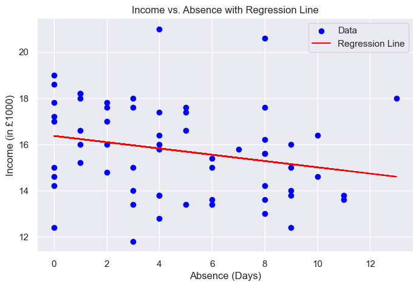

```python
# removed missing values from dataset
X = data_cleaned[['absence']]
y = data_cleaned[['income']]
model = LinearRegression()
model.fit(X, y)

y_pred = model.predict(X)

r2 = r2_score(y, y_pred)
print(f"R-squared: {r2}")

plt.figure(figsize=(8, 5))
plt.scatter(data_cleaned['absence'], data_cleaned['income'], color='blue', label='Data')
plt.plot(data_cleaned['absence'], y_pred, color='red', label='Regression Line')
plt.title('Income vs. Absence with Regression Line')
plt.xlabel('Absence (Days)')
plt.ylabel('Income (in £1000)')
plt.legend()
plt.show()
```

```
R-squared: 0.061913392866861816
```

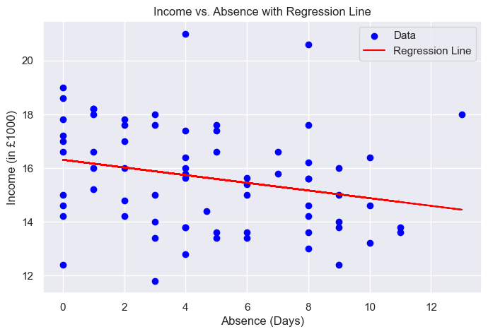

```python
# fill missing values
data_set['absence'] = data_set['absence'].fillna(data_set['absence'].mean())
data_set['income'] = data_set['income'].fillna(data_set['income'].mean())

X = data_set[['absence']]
y = data_set[['income']]

model = LinearRegression()
model.fit(X, y)

y_pred = model.predict(X)

r2 = r2_score(y, y_pred)
print(f"R-squared: {r2}")

plt.figure(figsize=(8, 5))
plt.scatter(data_set['absence'], data_set['income'], color='blue', label='Data')
plt.plot(data_set['absence'], y_pred, color='red', label='Regression Line')
plt.title('Income vs. Absence with Regression Line')
plt.xlabel('Absence (Days)')
plt.ylabel('Income (in £1000)')
plt.legend()
plt.show()
```

#### Part One: 3. Multiple Regression

- Study a multiple regression model where satis (job satisfaction) is the dependent variable, and the following are independent variables: commit, autonom, income, skill, qual, age, and years.
- Identify non-significant variables and simplify the model by removing them.

```python
X_multi = data_set_with_mean[['commit', 'autonom', 'income', 'skill', 'qual', 'age', 'years']]
y_multi = data_set_with_mean['satis']


# Add a constant to the model (required for statsmodels to include an intercept)
X_multi = sm.add_constant(X_multi)

# Step 5: Fit the multiple regression model
model = sm.OLS(y_multi, X_multi).fit()

# Step 6: View the summary of the model
print(model.summary())
```

```
                            OLS Regression Results
==============================================================================
Dep. Variable:                  satis   R-squared:                       0.805
Model:                            OLS   Adj. R-squared:                  0.783
Method:                 Least Squares   F-statistic:                     36.55
Date:                Sun, 08 Dec 2024   Prob (F-statistic):           1.08e-19
Time:                        22:31:00   Log-Likelihood:                -124.24
No. Observations:                  70   AIC:                             264.5
Df Residuals:                      62   BIC:                             282.5
Df Model:                           7
Covariance Type:            nonrobust
==============================================================================
                 coef    std err          t      P>|t|      [0.025      0.975]
------------------------------------------------------------------------------
const         -4.9905      1.697     -2.940      0.005      -8.383      -1.598
commit         0.9387      0.201      4.660      0.000       0.536       1.341
autonom        0.4204      0.086      4.873      0.000       0.248       0.593
income         0.4461      0.143      3.126      0.003       0.161       0.731
skill          0.5701      0.186      3.066      0.003       0.198       0.942
qual           0.2544      0.152      1.669      0.100      -0.050       0.559
age            0.0033      0.033      0.098      0.922      -0.063       0.070
years         -0.0047      0.032     -0.146      0.885      -0.069       0.059
==============================================================================
Omnibus:                        0.685   Durbin-Watson:                   2.114
Prob(Omnibus):                  0.710   Jarque-Bera (JB):                0.781
Skew:                          -0.114   Prob(JB):                        0.677
Kurtosis:                       2.536   Cond. No.                         445.
==============================================================================

Notes:
[1] Standard Errors assume that the covariance matrix of the errors is correctly specified.
```

```python
X_simplified = data_set_with_mean[['commit', 'autonom', 'income', 'skill', 'qual']]  # Remove 'age' and 'years'

# Add a constant to the simplified model
X_simplified = sm.add_constant(X_simplified)

# Step 8: Refit the simplified model
model_simplified = sm.OLS(y_multi, X_simplified).fit()

# Step 9: View the summary of the simplified model
print(model_simplified.summary())
```

```
                            OLS Regression Results
==============================================================================
Dep. Variable:                  satis   R-squared:                       0.805
Model:                            OLS   Adj. R-squared:                  0.790
Method:                 Least Squares   F-statistic:                     52.80
Date:                Sun, 08 Dec 2024   Prob (F-statistic):           2.05e-21
Time:                        22:31:00   Log-Likelihood:                -124.25
No. Observations:                  70   AIC:                             260.5
Df Residuals:                      64   BIC:                             274.0
Df Model:                           5
Covariance Type:            nonrobust
==============================================================================
                 coef    std err          t      P>|t|      [0.025      0.975]
------------------------------------------------------------------------------
const         -4.9868      1.565     -3.186      0.002      -8.114      -1.860
commit         0.9343      0.188      4.958      0.000       0.558       1.311
autonom        0.4227      0.082      5.170      0.000       0.259       0.586
income         0.4499      0.106      4.226      0.000       0.237       0.663
skill          0.5715      0.183      3.130      0.003       0.207       0.936
qual           0.2520      0.146      1.721      0.090      -0.040       0.544
==============================================================================
Omnibus:                        0.576   Durbin-Watson:                   2.100
Prob(Omnibus):                  0.750   Jarque-Bera (JB):                0.702
Skew:                          -0.103   Prob(JB):                        0.704
Kurtosis:                       2.555   Cond. No.                         168.
==============================================================================

Notes:
[1] Standard Errors assume that the covariance matrix of the errors is correctly specified.
```

## Part One: 4. Confidence Intervals

- Calculate the confidence interval for job satisfaction and the confidence interval for the difference between men and women.

```python
mean_satis = data_set_with_mean['satis'].mean()
std_satis = data_set_with_mean['satis'].std()
n_satis = len(data_set_with_mean['satis'])
#print(f"Mean of satis: {mean_satis}, Standard Deviation of satis: {std_satis}, n = {n_satis}")
# Calculate standard error
se_satis = std_satis / np.sqrt(n_satis)

# Calculate 95% confidence interval
ci_satis = stats.t.interval(0.95, df=n_satis-1, loc=mean_satis, scale=se_satis)
ci_satis_clean = tuple(map(float, ci_satis))
print(f"Confidence Interval for Job Satisfaction (satis): {ci_satis_clean}")

satis_men = data_set_with_mean[data_set_with_mean['gender'] == 1]['satis']
satis_women = data_set[data_set_with_mean['gender'] == 2]['satis']

mean_men = satis_men.mean()
mean_women = satis_women.mean()

std_men = satis_men.std()
std_women = satis_women.std()

n_men = len(satis_men)
n_women = len(satis_women)

# Standard error of the difference
se_diff = np.sqrt((std_men**2 / n_men) + (std_women**2 / n_women))

# Mean difference
mean_diff = mean_men - mean_women

# 95% confidence interval for the difference in means
ci_diff = stats.t.interval(0.95, df=min(n_men, n_women)-1, loc=mean_diff, scale=se_diff)
ci_diff_clean = tuple(map(float, ci_diff))
print(f"Confidence Interval for the Difference in Job Satisfaction between Men and Women: {ci_diff_clean}")
```

```
Confidence Interval for Job Satisfaction (satis): (10.062020962148376, 11.614449626086921)
Confidence Interval for the Difference in Job Satisfaction between Men and Women: (-1.3849796796368963, 1.8464694864777484)
```

## Part One: 5.Mann-Whitney and Kruskal-Wallis Tests

- Use the Mann-Whitney-Wilcoxon test to check if there is a significant difference in skill levels between men and women. Compare the results with the confidence interval.
- Use the Kruskal-Wallis test to determine if there is a significant difference in absence among ethnic groups. Compare this with results from One-Way ANOVA.

```python
##Mann-Whitney-Wilcoxon Test
# Split data into two groups based on gender
men_skills = data_cleaned[data_cleaned['gender'] == 1]['skill']
women_skills = data_cleaned[data_cleaned['gender'] == 2]['skill']

# Perform Mann-Whitney U test
stat, p_value = mannwhitneyu(men_skills, women_skills)

# Display the results
print(f"Mann-Whitney U Test Statistic: {stat}, p-value: {p_value}")

if p_value < 0.05:
    print("Reject the null hypothesis: There is a significant difference in skill levels between men and women.")
else:
    print("Fail to reject the null hypothesis: There is no significant difference in skill levels between men and women.")
```

```
Mann-Whitney U Test Statistic: 520.5, p-value: 0.4032893852621183
Fail to reject the null hypothesis: There is no significant difference in skill levels between men and women.
```

```python
## Kruskal-Wallis Test

# Split data by ethnic groups
ethnic_groups = [data_cleaned[data_cleaned['ethnicgp'] == i]['absence'] for i in data_cleaned['ethnicgp'].unique()]

# Perform Kruskal-Wallis H test
stat, p_value = kruskal(*ethnic_groups)

print(f"Kruskal-Wallis Test Statistic: {stat}, p-value: {p_value}")

if p_value < 0.05:
    print("Reject the null hypothesis: There is a significant difference in absence among ethnic groups.")
else:
    print("Fail to reject the null hypothesis: There is no significant difference in absence among ethnic groups.")
```

```
Kruskal-Wallis Test Statistic: 2.4084534950343763, p-value: 0.49206294724690613
Fail to reject the null hypothesis: There is no significant difference in absence among ethnic groups.
```

```python
anova_stat, anova_p_value = f_oneway(*ethnic_groups)

# Display the results
print(f"One-Way ANOVA Test Statistic: {anova_stat}, p-value: {anova_p_value}")

if anova_p_value < 0.05:
    print("Reject the null hypothesis: There is a significant difference in absence among ethnic groups.")
else:
    print("Fail to reject the null hypothesis: There is no significant difference in absence among ethnic groups.")
```

```
One-Way ANOVA Test Statistic: 0.8043403320870688, p-value: 0.4966477589834961
Fail to reject the null hypothesis: There is no significant difference in absence among ethnic groups.
```

## Part one: 6. Income Class Recode

- Recode income into income classes using the following ranges:
- Low income class: [Min, Q1]
- Middle income class: (Q1, Q3]
- High income class: (Q3, Max]
- Investigate if there is a significant relationship between income class and skill.

```python
Q1 = data_cleaned['income'].quantile(0.25)
Q3 = data_cleaned['income'].quantile(0.75)
min_income = data_cleaned['income'].min()
max_income = data_cleaned['income'].max()

# Recode the income into classes
def income_class(row):
    if row['income'] <= Q1:
        return 'Low Income'
    elif Q1 < row['income'] <= Q3:
        return 'Middle Income'
    else:
        return 'High Income'

data_set['income_class'] = data_set.apply(income_class, axis=1)

# Display the first few rows to check the recoding
print(data_set[['income', 'income_class']].head())
```

```
   income   income_class
0    16.6  Middle Income
1    14.6  Middle Income
2    17.8    High Income
3    16.4  Middle Income
4    18.6    High Income
```

```python
data_cleaned = data_set[['income_class', 'skill']].dropna()

# Split the data based on income class
low_income_skills = data_cleaned[data_cleaned['income_class'] == 'Low Income']['skill']
middle_income_skills = data_cleaned[data_cleaned['income_class'] == 'Middle Income']['skill']
high_income_skills = data_cleaned[data_cleaned['income_class'] == 'High Income']['skill']

# Perform the Kruskal-Wallis test
stat, p_value = kruskal(low_income_skills, middle_income_skills, high_income_skills)

# Display the results
print(f"Kruskal-Wallis Test Statistic: {stat}, p-value: {p_value}")

if p_value < 0.05:
    print("Reject the null hypothesis: There is a significant relationship between income class and skill.")
else:
    print("Fail to reject the null hypothesis: There is no significant relationship between income class and skill.")
```

```
Kruskal-Wallis Test Statistic: 8.1833181642631, p-value: 0.016711484820370597
Reject the null hypothesis: There is a significant relationship between income class and skill.
```